# Exploring mtcars dataset

### You work for Motor Trend, a magazine about the automobile industry. Looking at a data set of a collection of cars, they are interested in exploring the relationship between a set of variables and miles per gallon (MPG) (outcome).

## Data attributes

• (mpg) Miles/(US) gallon.

• (cyl) Number of cylinders.

• (disp) Displacement (cu.in.).

• (hp) Gross horsepower.

• (drat) Rear axle ratio.

• (wt) Weight (1000 lbs).

• (qsec) 1/4 mile time.

• (vs) Engine (0 = V-shaped, 1 = straight).

• (am) Transmission (0 = automatic, 1 = manual).

• (gear) Number of forward gears.

• (carb) Number of carburetors.

## Imports

```r
library("ggplot2")
library("reshape2")
```

# Adding the Dataset

```r
df = mtcars
print(df)
```

```
##                      mpg cyl  disp  hp drat    wt  qsec vs am gear carb
## Mazda RX4           21.0   6 160.0 110 3.90 2.620 16.46  0  1    4    4
## Mazda RX4 Wag       21.0   6 160.0 110 3.90 2.875 17.02  0  1    4    4
## Datsun 710          22.8   4 108.0  93 3.85 2.320 18.61  1  1    4    1
## Hornet 4 Drive      21.4   6 258.0 110 3.08 3.215 19.44  1  0    3    1
## Hornet Sportabout   18.7   8 360.0 175 3.15 3.440 17.02  0  0    3    2
## Valiant             18.1   6 225.0 105 2.76 3.460 20.22  1  0    3    1
## Duster 360          14.3   8 360.0 245 3.21 3.570 15.84  0  0    3    4
## Merc 240D           24.4   4 146.7  62 3.69 3.190 20.00  1  0    4    2
## Merc 230            22.8   4 140.8  95 3.92 3.150 22.90  1  0    4    2
## Merc 280            19.2   6 167.6 123 3.92 3.440 18.30  1  0    4    4
## Merc 280C           17.8   6 167.6 123 3.92 3.440 18.90  1  0    4    4
## Merc 450SE          16.4   8 275.8 180 3.07 4.070 17.40  0  0    3    3
## Merc 450SL          17.3   8 275.8 180 3.07 3.730 17.60  0  0    3    3
## Merc 450SLC         15.2   8 275.8 180 3.07 3.780 18.00  0  0    3    3
## Cadillac Fleetwood  10.4   8 472.0 205 2.93 5.250 17.98  0  0    3    4
## Lincoln Continental 10.4   8 460.0 215 3.00 5.424 17.82  0  0    3    4
## Chrysler Imperial   14.7   8 440.0 230 3.23 5.345 17.42  0  0    3    4
## Fiat 128            32.4   4  78.7  66 4.08 2.200 19.47  1  1    4    1
## Honda Civic         30.4   4  75.7  52 4.93 1.615 18.52  1  1    4    2
## Toyota Corolla      33.9   4  71.1  65 4.22 1.835 19.90  1  1    4    1
## Toyota Corona       21.5   4 120.1  97 3.70 2.465 20.01  1  0    3    1
## Dodge Challenger    15.5   8 318.0 150 2.76 3.520 16.87  0  0    3    2
## AMC Javelin         15.2   8 304.0 150 3.15 3.435 17.30  0  0    3    2
## Camaro Z28          13.3   8 350.0 245 3.73 3.840 15.41  0  0    3    4
## Pontiac Firebird    19.2   8 400.0 175 3.08 3.845 17.05  0  0    3    2
## Fiat X1-9           27.3   4  79.0  66 4.08 1.935 18.90  1  1    4    1
## Porsche 914-2       26.0   4 120.3  91 4.43 2.140 16.70  0  1    5    2
## Lotus Europa        30.4   4  95.1 113 3.77 1.513 16.90  1  1    5    2
## Ford Pantera L      15.8   8 351.0 264 4.22 3.170 14.50  0  1    5    4
## Ferrari Dino        19.7   6 145.0 175 3.62 2.770 15.50  0  1    5    6
## Maserati Bora       15.0   8 301.0 335 3.54 3.570 14.60  0  1    5    8
## Volvo 142E          21.4   4 121.0 109 4.11 2.780 18.60  1  1    4    2
```

## The relation between Weight(wt) and Mile Per Gallon(mpg).

#### Conclusion: by increasing of car weight the distance travelled per gallon decreases.

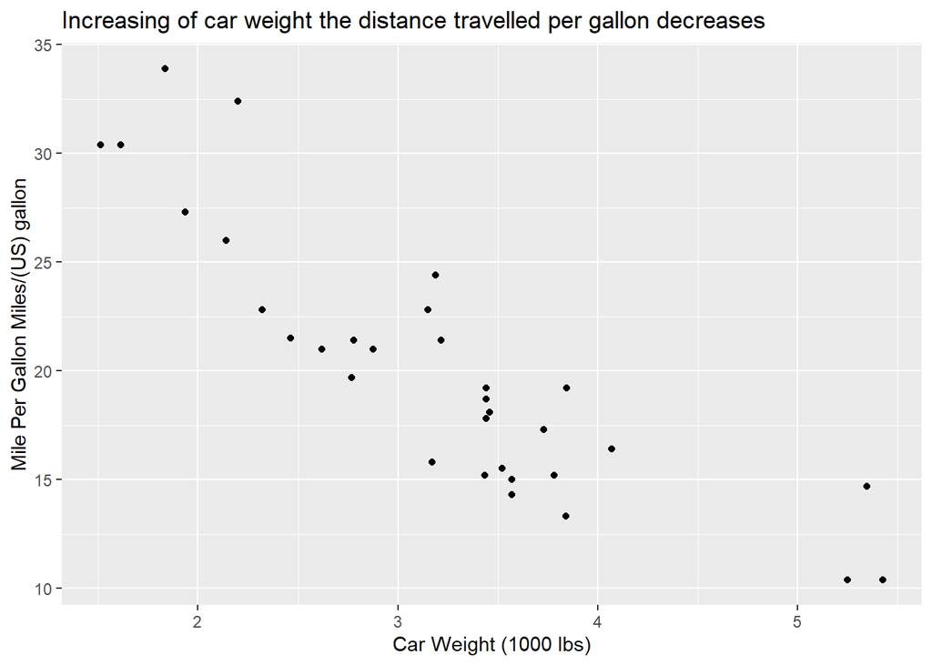

```r
plt_1 = ggplot(df, aes(x=wt,y=mpg)) + geom_point()
print(
  plt_1 +
    ggtitle("Increasing of car weight the distance travelled per gallon decreases") +
    labs(y = "Mile Per Gallon Miles/(US) gallon", x = "Car Weight (1000 lbs)")
  )
```

## The relation between Mile Per Gallon(mpg) and transmission(am) according to being automatic or manual .

#### 1 = Manual.

#### 0 = Automatic.

#### Conclusion: Manual cars travel more miles per gallon.

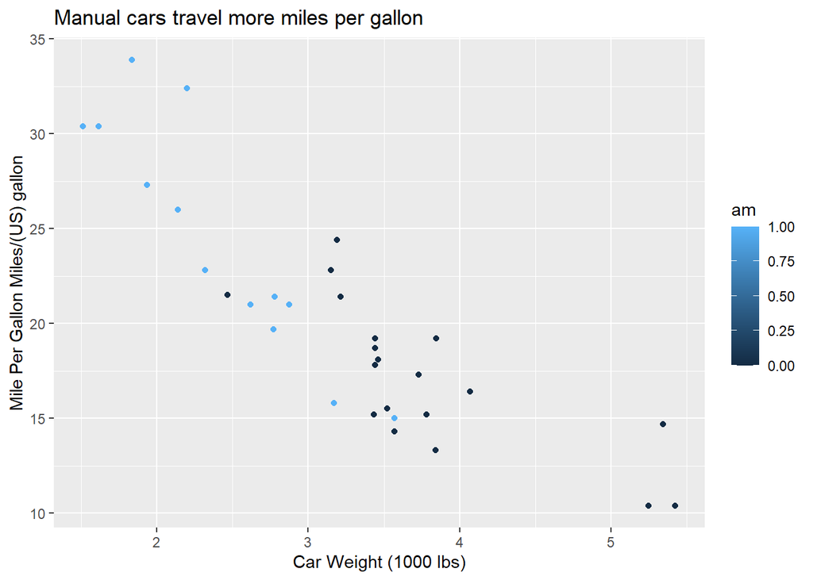

```r
plt_2 = ggplot(df,aes(x=wt,y=mpg,group=am)) +
        geom_point(aes(color=am)
        )

print(
  plt_2 +
    ggtitle("Manual cars travel more miles per gallon") +
    labs(y = "Mile Per Gallon Miles/(US) gallon", x = "Car Weight (1000 lbs)")
      )
```

## Quantify the MPG difference between automatic and manual transmissions.

[figure not shown]

```r
# barplot
# sum of Miles per gallon for manual cars
# sum of Miles per gallon for automatic cars

mpg_sum_auto <- sum(df[which(df$am==0), 1])
mpg_sum_manual <- sum(df[which(df$am==1), 1])
mpg_diff = mpg_sum_auto - mpg_sum_manual

ggplot(data=df, aes(x=am, y=mpg))+
  geom_bar(stat="identity", width=0.7, fill="steelblue") +
  ggtitle(paste("Sum of automatic MPG = ", mpg_sum_auto , " Miles\nSum of manual MPG = ", mpg_sum_manual , " Miles\nDifference = " , mpg_diff , " Miles")) +
  labs(y = "Total Miles Per Gallon Miles/(US) gallon", x = "Car Weight (1000 lbs)")
```

## Relationships between multiple variables using corellation mx.

```r
cormat <- round(cor(df),2)
head(cormat)
```

```
##        mpg   cyl  disp    hp  drat    wt  qsec    vs    am  gear  carb
## mpg   1.00 -0.85 -0.85 -0.78  0.68 -0.87  0.42  0.66  0.60  0.48 -0.55
## cyl  -0.85  1.00  0.90  0.83 -0.70  0.78 -0.59 -0.81 -0.52 -0.49  0.53
## disp -0.85  0.90  1.00  0.79 -0.71  0.89 -0.43 -0.71 -0.59 -0.56  0.39
## hp   -0.78  0.83  0.79  1.00 -0.45  0.66 -0.71 -0.72 -0.24 -0.13  0.75
## drat  0.68 -0.70 -0.71 -0.45  1.00 -0.71  0.09  0.44  0.71  0.70 -0.09
## wt   -0.87  0.78  0.89  0.66 -0.71  1.00 -0.17 -0.55 -0.69 -0.58  0.43
```

### melt():

#### It enables us to reshape and elongate the data frames.

#### It organizes the data values in a long data frame format.

#### we need it in this elongated shape to plot the Heatmap.

```r
melted_cormat <- melt(cormat)
head(melted_cormat)
```

```
##   Var1 Var2 value
## 1  mpg  mpg  1.00
## 2  cyl  mpg -0.85
## 3 disp  mpg -0.85
## 4   hp  mpg -0.78
## 5 drat  mpg  0.68
## 6   wt  mpg -0.87
```

### We will use heatmap to analyze at least one dependent variable and three independent variables.

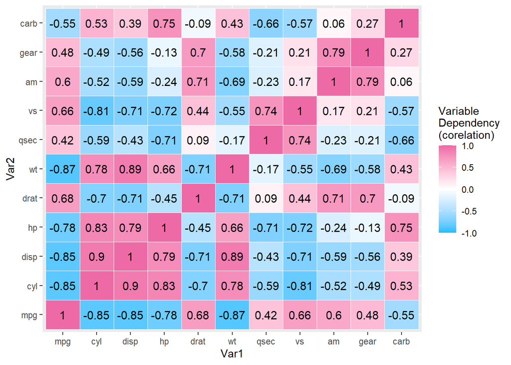

```r
ggplot(data = melted_cormat, aes(x=Var1, y=Var2, fill=value , label = value), color = "black", size = 4 ) +

  geom_tile(color = "white") +
 scale_fill_gradient2(low = "deepskyblue1", high = "hotpink2", mid = "white",
   midpoint = 0, limit = c(-1,1), space = "Lab",
   name="Variable\nDependency\n(corelation)") +

  geom_text(aes(Var2, Var1, label = value), color = "black", size = 4)
```

#### Conclusion

Dependent variable: the variable will be dependent when the correlation is the largest. Independent variable: the variable will be independent when the correlation is the smallest.

```r
# for general dependency

dependency = colMeans(cormat)
print(dependency)
```

```
##          mpg          cyl         disp           hp         drat           wt
## -0.005454545  0.007272727  0.010909091  0.090909091  0.087272727  0.017272727
##         qsec           vs           am         gear         carb
## -0.068181818 -0.012727273  0.096363636  0.134545455  0.141818182
```

```r
# large number means dependent (correlated) on the rest of the features.
# small number means independent (uncorrelated) on the rest of the features.
```

## To find the best model fit to explain the relationship between the set of variables and miles per gallon (MPG) through a variable selection procedure called stepwise regression.

```r
# lock the randomization process
set.seed(42)

# choose random indices and set them as training/testing sets
n = nrow(mtcars)
index = sample(n, n*0.80, replace = FALSE)
train_set = mtcars[index,]
test_set = mtcars[-index,]

train_set
```

```
##                      mpg cyl  disp  hp drat    wt  qsec vs am gear carb
## Chrysler Imperial   14.7   8 440.0 230 3.23 5.345 17.42  0  0    3    4
## Hornet Sportabout   18.7   8 360.0 175 3.15 3.440 17.02  0  0    3    2
## Mazda RX4           21.0   6 160.0 110 3.90 2.620 16.46  0  1    4    4
## Pontiac Firebird    19.2   8 400.0 175 3.08 3.845 17.05  0  0    3    2
## Merc 280            19.2   6 167.6 123 3.92 3.440 18.30  1  0    4    4
## Hornet 4 Drive      21.4   6 258.0 110 3.08 3.215 19.44  1  0    3    1
## Fiat 128            32.4   4  78.7  66 4.08 2.200 19.47  1  1    4    1
## Volvo 142E          21.4   4 121.0 109 4.11 2.780 18.60  1  1    4    2
## Cadillac Fleetwood  10.4   8 472.0 205 2.93 5.250 17.98  0  0    3    4
## Duster 360          14.3   8 360.0 245 3.21 3.570 15.84  0  0    3    4
## Porsche 914-2       26.0   4 120.3  91 4.43 2.140 16.70  0  1    5    2
## Maserati Bora       15.0   8 301.0 335 3.54 3.570 14.60  0  1    5    8
## Merc 450SLC         15.2   8 275.8 180 3.07 3.780 18.00  0  0    3    3
## Fiat X1-9           27.3   4  79.0  66 4.08 1.935 18.90  1  1    4    1
## Camaro Z28          13.3   8 350.0 245 3.73 3.840 15.41  0  0    3    4
## Datsun 710          22.8   4 108.0  93 3.85 2.320 18.61  1  1    4    1
## Merc 230            22.8   4 140.8  95 3.92 3.150 22.90  1  0    4    2
## Lincoln Continental 10.4   8 460.0 215 3.00 5.424 17.82  0  0    3    4
## Merc 280C           17.8   6 167.6 123 3.92 3.440 18.90  1  0    4    4
## Dodge Challenger    15.5   8 318.0 150 2.76 3.520 16.87  0  0    3    2
## Toyota Corona       21.5   4 120.1  97 3.70 2.465 20.01  1  0    3    1
## Merc 450SE          16.4   8 275.8 180 3.07 4.070 17.40  0  0    3    3
## Merc 450SL          17.3   8 275.8 180 3.07 3.730 17.60  0  0    3    3
## Mazda RX4 Wag       21.0   6 160.0 110 3.90 2.875 17.02  0  1    4    4
## Lotus Europa        30.4   4  95.1 113 3.77 1.513 16.90  1  1    5    2
```

```r
test_set
```

```
##                 mpg cyl  disp  hp drat    wt  qsec vs am gear carb
## Valiant        18.1   6 225.0 105 2.76 3.460 20.22  1  0    3    1
## Merc 240D      24.4   4 146.7  62 3.69 3.190 20.00  1  0    4    2
## Honda Civic    30.4   4  75.7  52 4.93 1.615 18.52  1  1    4    2
## Toyota Corolla 33.9   4  71.1  65 4.22 1.835 19.90  1  1    4    1
## AMC Javelin    15.2   8 304.0 150 3.15 3.435 17.30  0  0    3    2
## Ford Pantera L 15.8   8 351.0 264 4.22 3.170 14.50  0  1    5    4
## Ferrari Dino   19.7   6 145.0 175 3.62 2.770 15.50  0  1    5    6
```

## Forward Selection

```r
# combination of regression
# mpg with < cyl , disp , hp , drat , wt , qsec , vs , am , gear , carb >

model_full = lm(mpg ~ ., data = train_set)
model_int = lm(mpg ~ -., data = train_set)

scopeformula = formula(model_full)
scopeformula
```

```
## mpg ~ cyl + disp + hp + drat + wt + qsec + vs + am + gear + carb
```

```r
fwd_sel = step(object=model_int, scope=scopeformula, direction="forward")
```

```
## Start:  AIC=87.12
## mpg ~ -(cyl + disp + hp + drat + wt + qsec + vs + am + gear +
##     carb)
##
##        Df Sum of Sq    RSS    AIC
## + wt    1    584.02 168.65 51.724
## + cyl   1    535.96 216.71 57.992
## + disp  1    535.59 217.09 58.036
## + hp    1    453.50 299.17 66.053
## + drat  1    350.40 402.27 73.456
## + am    1    314.41 438.26 75.599
## + vs    1    305.88 446.80 76.081
## + carb  1    276.35 476.32 77.681
## + gear  1    273.23 479.45 77.844
## + qsec  1     98.75 653.93 85.603
## <none>              752.67 87.119
##
## Step:  AIC=51.72
## mpg ~ wt
##
##        Df Sum of Sq    RSS    AIC
## + hp    1    40.499 128.16 46.859
## + cyl   1    39.051 129.60 47.140
## + qsec  1    33.947 134.71 48.106
## + carb  1    29.284 139.37 48.956
## + vs    1    20.075 148.58 50.556
## <none>              168.65 51.724
## + disp  1     9.847 158.81 52.220
## + drat  1     5.749 162.91 52.857
## + am    1     2.979 165.68 53.279
## + gear  1     2.414 166.24 53.364
##
## Step:  AIC=46.86
## mpg ~ wt + hp
##
##        Df Sum of Sq    RSS    AIC
## + gear  1   11.8650 116.29 46.430
## <none>              128.16 46.859
## + am    1    9.5934 118.56 46.914
## + cyl   1    8.7179 119.44 47.098
```

[output cut: 15 more lines]

```
## + vs    1    1.6325 114.657 48.077
## + am    1    1.5084 114.781 48.104
## + drat  1    1.0112 115.279 48.212
##
## Step:  AIC=41.57
## mpg ~ wt + hp + gear + carb
##
##        Df Sum of Sq    RSS    AIC
## <none>              88.376 41.568
## + am    1   1.62856 86.747 43.103
## + qsec  1   0.63586 87.740 43.387
## + vs    1   0.30589 88.070 43.481
## + cyl   1   0.21646 88.159 43.507
## + drat  1   0.15110 88.224 43.525
## + disp  1   0.01651 88.359 43.563
```

```r
summary(fwd_sel)
```

```
##
## Call:
## lm(formula = mpg ~ wt + hp + gear + carb, data = train_set)
##
## Residuals:
##     Min      1Q  Median      3Q     Max
## -3.1634 -0.9977  0.1162  0.7506  6.0119
##
## Coefficients:
##              Estimate Std. Error t value Pr(>|t|)
## (Intercept) 19.199406   5.869147   3.271  0.00382 **
## wt          -1.894817   0.850806  -2.227  0.03759 *
## hp          -0.007307   0.013328  -0.548  0.58956
## gear         3.338082   1.140195   2.928  0.00832 **
## carb        -1.512742   0.601871  -2.513  0.02063 *
## ---
## Signif. codes:  0 '***' 0.001 '**' 0.01 '*' 0.05 '.' 0.1 ' ' 1
##
## Residual standard error: 2.102 on 20 degrees of freedom
## Multiple R-squared:  0.8826, Adjusted R-squared:  0.8591
## F-statistic: 37.58 on 4 and 20 DF,  p-value: 4.894e-09
```

## Backward Selection

```r
model_full = lm(mpg ~ ., data = train_set)
scopeformula = formula(model_full)

back_sel = step(object=model_full, scope=scopeformula, direction="backward")
```

```
## Start:  AIC=49.12
## mpg ~ cyl + disp + hp + drat + wt + qsec + vs + am + gear + carb
##
##        Df Sum of Sq    RSS    AIC
## - hp    1    0.1823 74.140 47.177
## - disp  1    0.8426 74.800 47.399
## - vs    1    2.9743 76.932 48.101
## - drat  1    4.9653 78.923 48.740
## <none>              73.958 49.115
## - qsec  1    7.3694 81.327 49.490
## - am    1    9.8119 83.770 50.230
## - cyl   1    9.8434 83.801 50.239
## - wt    1   11.3458 85.304 50.684
## - carb  1   19.3245 93.282 52.919
## - gear  1   19.8357 93.793 53.055
##
## Step:  AIC=47.18
## mpg ~ cyl + disp + drat + wt + qsec + vs + am + gear + carb
##
##        Df Sum of Sq     RSS    AIC
## - disp  1     0.662  74.802 45.399
## - vs    1     2.805  76.945 46.105
## - drat  1     5.250  79.390 46.887
## <none>               74.140 47.177
## - qsec  1     7.883  82.023 47.703
## - am    1    10.014  84.154 48.344
## - cyl   1    10.020  84.160 48.346
## - wt    1    11.497  85.637 48.781
## - gear  1    20.554  94.694 51.294
## - carb  1    34.785 108.926 54.795
##
## Step:  AIC=45.4
## mpg ~ cyl + drat + wt + qsec + vs + am + gear + carb
##
##        Df Sum of Sq     RSS    AIC
## - vs    1     2.493  77.295 44.219
## - drat  1     4.590  79.392 44.888
## <none>               74.802 45.399
## - qsec  1     7.778  82.580 45.872
## - am    1     9.383  84.185 46.354
```

[output cut: 44 more lines]

```
##        Df Sum of Sq     RSS    AIC
## - qsec  1     1.627  89.704 39.941
## <none>               88.077 41.483
## - wt    1    24.758 112.835 45.676
## - carb  1    38.274 126.351 48.505
## - gear  1    40.492 128.568 48.940
##
## Step:  AIC=39.94
## mpg ~ wt + gear + carb
##
##        Df Sum of Sq     RSS    AIC
## <none>               89.704 39.941
## - wt    1    23.284 112.988 43.710
## - gear  1    49.666 139.370 48.956
## - carb  1    76.536 166.240 53.364
```

```r
summary(back_sel)
```

```
##
## Call:
## lm(formula = mpg ~ wt + gear + carb, data = train_set)
##
## Residuals:
##     Min      1Q  Median      3Q     Max
## -3.3095 -1.0111  0.0519  0.7523  6.0574
##
## Coefficients:
##             Estimate Std. Error t value Pr(>|t|)
## (Intercept)  18.1093     5.4294   3.335 0.003139 **
## wt           -1.9427     0.8321  -2.335 0.029565 *
## gear          3.5641     1.0452   3.410 0.002636 **
## carb         -1.7490     0.4132  -4.233 0.000372 ***
## ---
## Signif. codes:  0 '***' 0.001 '**' 0.01 '*' 0.05 '.' 0.1 ' ' 1
##
## Residual standard error: 2.067 on 21 degrees of freedom
## Multiple R-squared:  0.8808, Adjusted R-squared:  0.8638
## F-statistic: 51.73 on 3 and 21 DF,  p-value: 7.132e-10
```

## Plotting for linear regression assumptions:

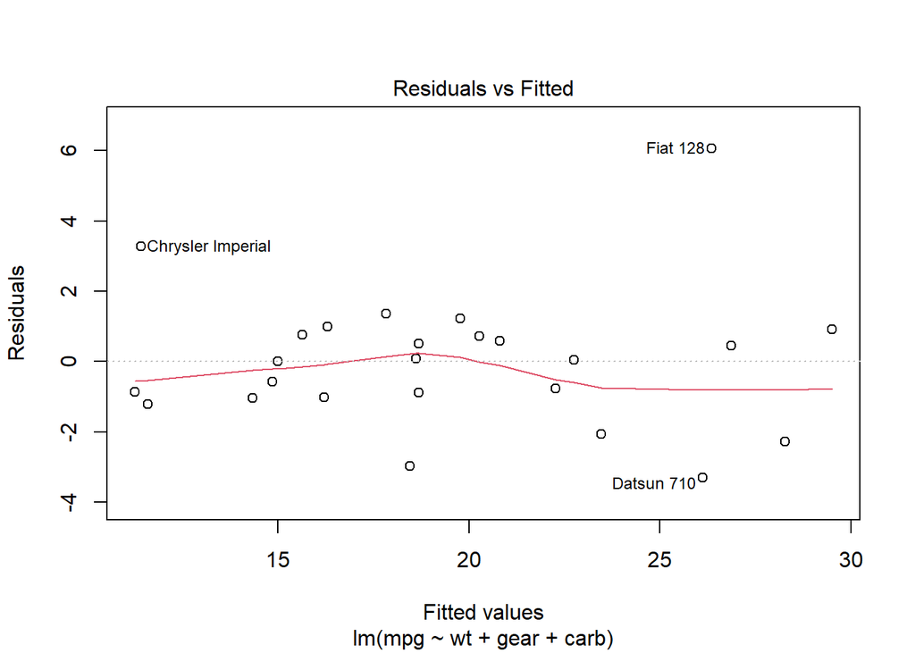

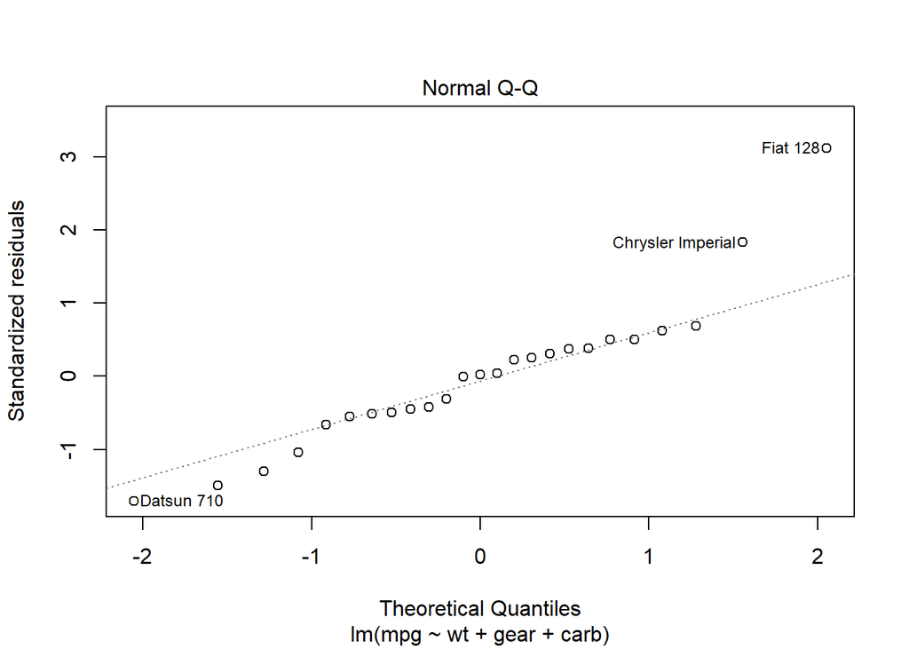

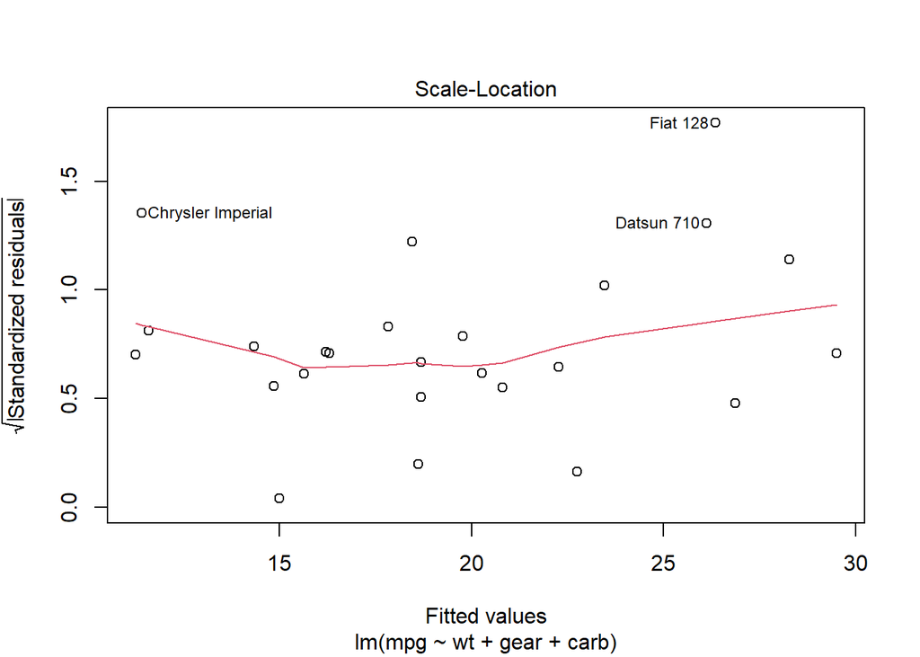

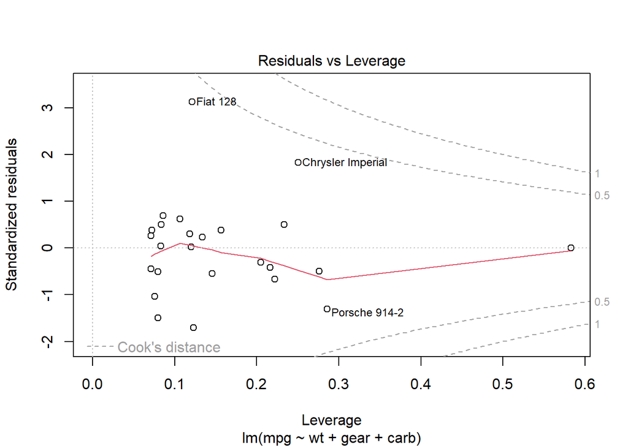

```r
plot(back_sel)
```